In this series we are trying to reproduce the models and examples listed in the book “Analysis of Financial Time Series, 3rd Edition”, by Ruey S. Tsay, using Stan https://mc-stan.org/ and the package RStan https://cran.r-project.org/web/packages/rstan/index.html. The main repository for the presented models and data can be found at https://github.com/marcomarconi/AFTS_with_Stan.

Most of the models listed in chapter 3 were already translated into Stan as part of the official documentation and can be found at https://mc-stan.org/docs/2_26/stan-users-guide/time-series-chapter.html. Still, we will go through them in the current document.

```r
{
  require(tidyverse)
  require(rstan)
  require(bayesplot)
  require(loo)
  require(LaplacesDemon)
  library(xts)
  library(quantmod)
  library(FKF)
  library(MARSS)
  library(forecast)
  rstan_options(auto_write = TRUE)
  rstan_options(javascript = FALSE)
  theme_set(theme_classic(base_size = 24))
}
```

## The GARCH Model

The typical GARCH(1,1) model can be coded in Stan as described in https://mc-stan.org/docs/2_26/stan-users-guide/modeling-temporal-heteroscedasticity.html.

We are going to fit this model and its extension AR(3)-GARCH(1) to the S&P500 data:

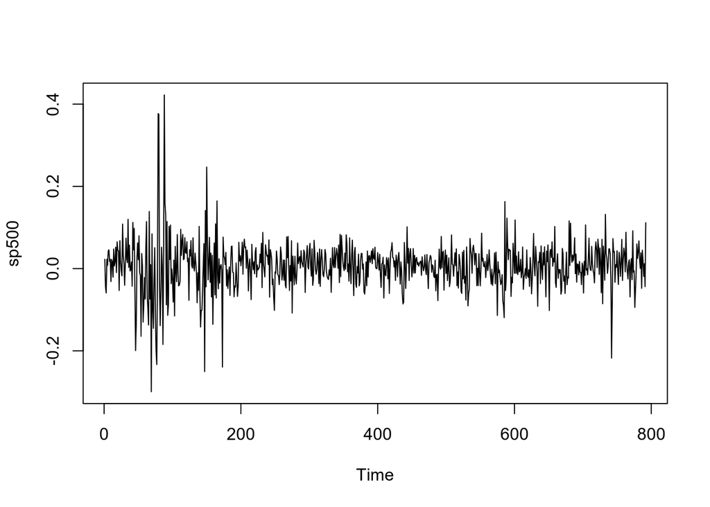

```r
sp500 <- scan("data/sp500.dat.txt")
plot.ts(sp500)
```

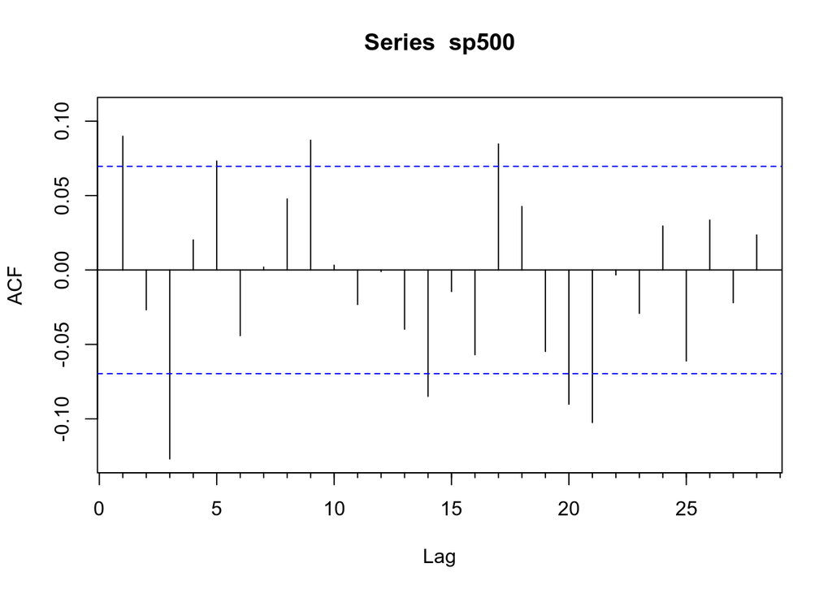

```r
Acf(sp500)
```

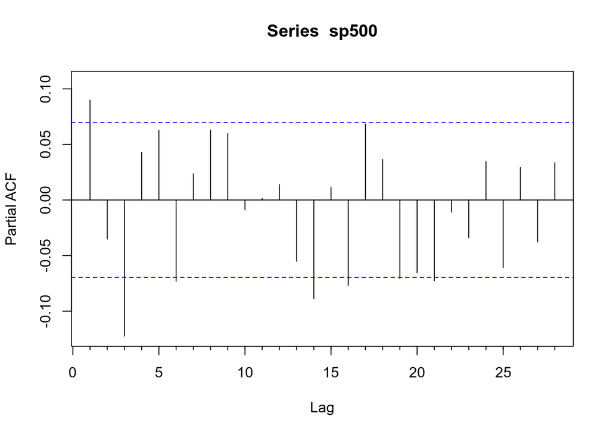

```r
Pacf(sp500)
```

A GARCH(K,K) model can be coded in Stan as follow:

```stan
data {
  int<lower=0> N;
  vector[N] y;
  int K;
  real sigma1;
}
parameters {
  real mu;
  real<lower=0> alpha0;
  real<lower=0,upper=1> alpha1;
  real<lower=0,upper=1> beta1;
}
transformed parameters {
  real<lower=0> sigma[N];
  for(i in 1:K)
    sigma[i] = sigma1;
  for (t in (K+1):N)
    sigma[t] = sqrt(alpha0
                    + alpha1 * pow(y[t-K] - mu, 2)
                    + beta1 * pow(sigma[t-1], 2));
}
model {
  y ~ normal(mu, sigma);
}
generated quantities {
   vector[N] log_lik;
   {
     for (t in 1:N)
        log_lik[t] = normal_lpdf(y[t] | mu, sigma[t]);

   }
}
```

While a AR(K)-GARCH(1,1) model can be coded in Stan as follow:

```stan
data {
  int<lower=0> N;
  vector[N] y;
  int K;

}
parameters {
  real<lower=0> alpha0;
  real<lower=0,upper=1> alpha1;
  real<lower=0,upper=(1-alpha1)> beta1;
  real<lower=0> sigma1;
  real ar0;
  vector[K] ar;

}
transformed parameters {
  real<lower=0> sigma[N];
  sigma[1] = sigma1;
  for (t in 2:N)
    sigma[t] = sqrt(alpha0
                    + alpha1 * pow(y[t-1] - ar0, 2)
                    + beta1 * pow(sigma[t-1], 2));
}
model {
  alpha0 ~ normal(0, 1);
  alpha1 ~ normal(0, 1);
  beta1 ~ normal(0, 1);
  sigma1 ~ cauchy(0, 1);
  ar0 ~ normal(0, 1);
  ar ~ normal(0, 1);
  for (n in (K+1):N) {
    real mu = ar0;
    for (k in 1:K)
      mu += ar[k] * y[n-k];
    y[n] ~ normal(mu, sigma[n]);
  }

}
generated quantities {
  vector[N] log_lik;
  {
    real log_lik_mu = 0;
    for (t in 1:K)
      log_lik[t] = normal_lpdf(y[t] | ar0 / (1 - sum(ar)), sigma[t]);
    for (t in (K+1):N) {
      real mu = ar0;
      for (k in 1:K)
        mu += ar[k] * y[t-k];
      log_lik[t] = normal_lpdf(y[t] | mu, sigma[t]);
      log_lik_mu += log_lik[t];
    }
    log_lik_mu /= N-(K+1);
    for (t in 1:K)
      log_lik[t] = log_lik_mu;
  }
}
```

Let’s fit both models to the data and check the estimated parameters:

```r
GARCH <- stan_model("models/Chapter_3/GARCH.stan")
ARGARCH <- stan_model("models/Chapter_3/AR-GARCH.stan")
fit_garch_sp500 <- sampling(GARCH, data = list(N = length(sp500), y = sp500, K = 1, sigma1 = sd(sp500)), chains = 4, refresh=0)
fit_argarch_sp500 <- sampling(ARGARCH, data = list(N = length(sp500), y = sp500, K = 3), chains = 4, refresh=0)
print(fit_garch_sp500, pars=names(fit_garch_sp500)[1:4], digits=5)
```

```
## Inference for Stan model: GARCH.
## 4 chains, each with iter=2000; warmup=1000; thin=1;
## post-warmup draws per chain=1000, total post-warmup draws=4000.
##
##           mean se_mean      sd    2.5%     25%     50%     75%   97.5% n_eff
## mu     0.00755 0.00002 0.00155 0.00456 0.00646 0.00755 0.00861 0.01053  4505
## alpha0 0.00009 0.00000 0.00003 0.00004 0.00007 0.00009 0.00011 0.00016  1383
## alpha1 0.13252 0.00063 0.02372 0.09164 0.11563 0.13085 0.14701 0.18334  1421
## beta1  0.84285 0.00063 0.02286 0.79597 0.82756 0.84453 0.85883 0.88338  1322
##           Rhat
## mu     0.99945
## alpha0 1.00294
## alpha1 1.00176
## beta1  1.00410
##
## Samples were drawn using NUTS(diag_e) at Sat May 15 20:58:05 2021.
## For each parameter, n_eff is a crude measure of effective sample size,
## and Rhat is the potential scale reduction factor on split chains (at
## convergence, Rhat=1).
```

```r
print(fit_argarch_sp500, pars=names(fit_argarch_sp500)[1:8], digits=5)
```

```
## Inference for Stan model: AR-GARCH.
## 4 chains, each with iter=2000; warmup=1000; thin=1;
## post-warmup draws per chain=1000, total post-warmup draws=4000.
##
##            mean se_mean      sd     2.5%      25%      50%     75%   97.5%
## alpha0  0.00009 0.00000 0.00003  0.00004  0.00007  0.00009 0.00011 0.00016
## alpha1  0.12492 0.00037 0.02160  0.08558  0.10964  0.12380 0.13899 0.17020
## beta1   0.84788 0.00039 0.02264  0.80091  0.83302  0.84872 0.86371 0.88960
## sigma1  0.02450 0.00032 0.02017  0.00080  0.00950  0.02020 0.03455 0.07304
## ar0     0.00766 0.00002 0.00166  0.00441  0.00656  0.00763 0.00877 0.01094
## ar[1]   0.02007 0.00068 0.04114 -0.06291 -0.00784  0.02073 0.04806 0.09819
## ar[2]  -0.00903 0.00064 0.03860 -0.08555 -0.03404 -0.00942 0.01693 0.06701
## ar[3]  -0.01074 0.00060 0.03944 -0.08747 -0.03672 -0.00984 0.01516 0.06690
##        n_eff    Rhat
## alpha0  2577 1.00053
## alpha1  3331 0.99982
## beta1   3419 0.99962
## sigma1  3913 1.00077
## ar0     5062 0.99945
## ar[1]   3635 1.00045
## ar[2]   3691 1.00018
## ar[3]   4349 0.99959
##
## Samples were drawn using NUTS(diag_e) at Sat May 15 20:59:00 2021.
## For each parameter, n_eff is a crude measure of effective sample size,
## and Rhat is the potential scale reduction factor on split chains (at
## convergence, Rhat=1).
```

Both models produce estimations that are in close agreement with the ones shown in the book.

In the book, the simpler GARCH(1,1) is preferred over the AR(3)-GARCH(1,1) because the AR coefficient of the latter are close to zero and deemed not significant. Let’s see what we get by comparing the two models with loo:

```r
a <- extract_log_lik(fit_garch_sp500, merge_chains = FALSE)[,,4:(length(sp500))]
b <- extract_log_lik(fit_argarch_sp500, merge_chains = FALSE)[,,4:(length(sp500))]
r_eff_a <- relative_eff(exp(a))
r_eff_b <- relative_eff(exp(b))
loo_compare(loo(a, r_eff = r_eff_a, moment_match = TRUE), loo(b, r_eff = r_eff_b, moment_match = TRUE))
```

```
##        elpd_diff se_diff
## model1  0.0       0.0
## model2 -0.9       0.9
```

We can see that there is little difference between the two models, and therefore the simpler model should be preferred.

We can finally have a look at the estimated volatility from the GARCH(1,1) model:

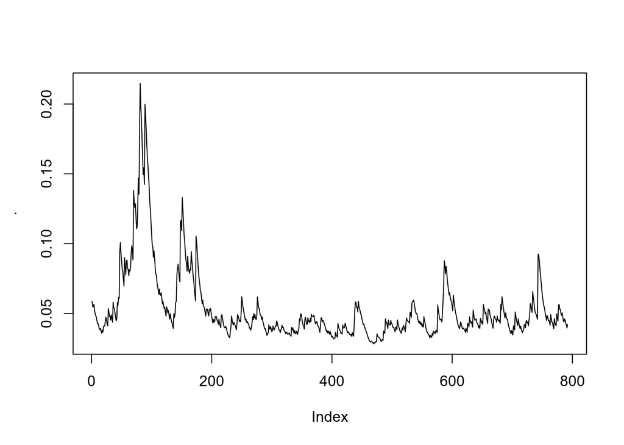

```r
extract(fit_garch_sp500, pars="sigma")[[1]] %>% colMeans()  %>% plot(type="l")
```

### Example 3.4

The example addresses the question on whether the daily volatility of a stock is lower in the summer and, if so, by how much. We will the IBM data:

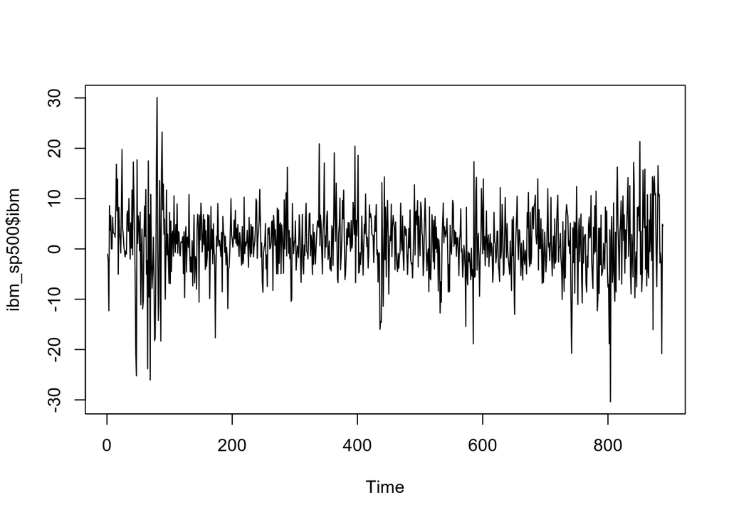

```r
ibm_sp500 <- read.table("data/m-ibmsplnsu.dat", header=T)
plot.ts(ibm_sp500$ibm)
```

Let’s fit a simple AR(1)-GARCH(1,1) model first, we will use it later:

```r
fit_argarch_ibm2 <- sampling(ARGARCH, data = list(N = length(ibm_sp500$ibm), y = ibm_sp500$ibm, K = 1), chains = 1, refresh=0)
```

To study the summer effect on stock volatility of an asset, we define an indicator variable “u” which takes the value 1 if the month is June, July or August, and 0 otherwise. We will the mode described in equation (3.45) in the book which imposes the constraint that the constant term of the volatility equation is zero for the summer months:

$$\sigma^2_t = \alpha_1\alpha^2_{t-1} + \beta_1\sigma^2_{t-1} + \gamma(1 - u_t)$$

Here is the code in Stan:

```stan
data {
  int<lower=0> N;
  real y[N];
  int u[N];
  int K;
}
parameters {
  real<lower=0,upper=1> alpha1;
  real<lower=0,upper=1> beta1;
  real<lower=0> sigma1;
  real gamma;
  real ar0;
  vector[K] ar;
}
transformed parameters {
  real<lower=0> sigma[N];
  sigma[1] = sigma1;
  for (t in 2:N)
    sigma[t] = sqrt(
                    alpha1 * pow(y[t-1] - ar0, 2)
                    + beta1 * pow(sigma[t-1], 2)
                    + gamma * (1 - u[t])

                    );
}
model {
  alpha1 ~ normal(0, 1);
  beta1 ~ normal(0, 1);
  sigma1 ~ cauchy(0, 1);
  ar0 ~ normal(0, 1);
  ar ~ normal(0, 1);
  for (n in (K+1):N) {
    real mu = ar0;
    for (k in 1:K)
      mu += ar[k] * y[n-k];
    y[n] ~ normal(mu, sigma[n]);
  }

}
generated quantities {
  vector[N] log_lik;
  {
    real log_lik_mu = 0;
    for (t in 1:K)
      log_lik[t] = normal_lpdf(y[t] | ar0 / (1 - sum(ar)), sigma[t]);
    for (t in (K+1):N) {
      real mu = ar0;
      for (k in 1:K)
        mu += ar[k] * y[t-k];
      log_lik[t] = normal_lpdf(y[t] | mu, sigma[t]);
      log_lik_mu += log_lik[t];
    }
    log_lik_mu /= N-(K+1);
    for (t in 1:K)
      log_lik[t] = log_lik_mu;
  }
}
```

Let’s fit it to the data:

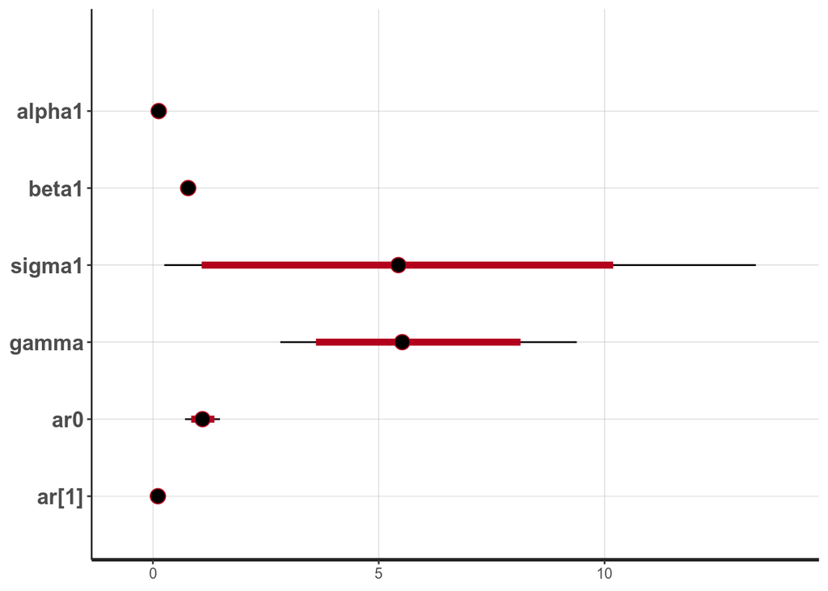

```r
ARGARCH_I <- stan_model("models/Chapter_3/AR-GARCH-I.stan")
fit_argarch_I_ibm2 <- sampling(ARGARCH_I, data = list(N = length(ibm_sp500$ibm), y = ibm_sp500$ibm, u = ibm_sp500$summer, K = 1), chains = 1, refresh=0)
plot(fit_argarch_I_ibm2, pars=names(fit_argarch_I_ibm2)[1:6])
```

You can clearly see that the gamma parameter is significantly different from zero.

We can compare the last model with the simple AR(1)-GARCH(1,1):

```r
loo_compare(loo(fit_argarch_ibm2, moment_match = TRUE), loo(fit_argarch_I_ibm2, moment_match = TRUE))
```

```
##        elpd_diff se_diff
## model2  0.0       0.0
## model1 -2.5       3.8
```

### Example 3.5

The question we ask in this example is whether the past returns of individual components of the index S&P 500 contribute to the modeling of the S&P 500 index volatility in the presence of its own returns. The IBM stock will be used as explanatory variable:

$$\sigma^2_t = \alpha_0 + \alpha_1\alpha^2_{t-1} + \alpha_2\alpha^2_{t-2} + \beta_1\sigma^2_{t-1} + \gamma(x_{t-1} - \bar{x})^2$$

Let’s have a look at the Stan code:

```stan
data {
  int<lower=0> N;
  real y[N];
  real x[N];
  int K;
}
transformed data {
  vector[N] x_std;
  real m = mean(x);
  real stdev = sd(x);
  x_std = (to_vector(x) - m) / stdev; // dividing by stdev avoids divergencies
}
parameters {
  real mu;
  real<lower=0> sigma1;
  real<lower=0> alpha0;
  real<lower=0,upper=1> alpha1;
  real<lower=0,upper=1> beta1;
  real gamma;
}
transformed parameters {
  real<lower=0> sigma[N];
  for(i in 1:K)
    sigma[i] = sigma1;
  for (t in (K+1):N)
    sigma[t] = sqrt(
                      alpha0
                    + alpha1 * pow(y[t-K] - mu, 2)
                    + beta1 * pow(sigma[t-1], 2)
                    + gamma * pow(x_std[t-1], 2)
                    )                    ;
}
model {
  mu ~ normal(0, 1);
  sigma1 ~ cauchy(0, 1);
  gamma ~ normal(0, 0.01);
  y ~ normal(mu, sigma);
}
generated quantities {
  vector[N] log_lik;
  for (t in 1:N)
      log_lik[t] = normal_lpdf(y[t] | mu, sigma[t]);

}
```

and fit it to the data, together with a simple GARCH(2,1) model:

```r
GARCH <- stan_model("models/Chapter_3/GARCH.stan")
fit_garch_sp500 <- sampling(GARCH , data=list(N = length(ibm_sp500$sp), y = ibm_sp500$sp, K = 2, sigma1=sd(ibm_sp500$sp)), chains = 4, refresh=0)
GARCH_x <- stan_model("models/Chapter_3/GARCH_x.stan")
fit_garch_x_sp500 <- sampling(GARCH_x , data=list(N = length(ibm_sp500$sp), y = ibm_sp500$sp, x=ibm_sp500$ibm, K = 2), chains = 4, refresh=0)
```

Contrary to the book (which estimate a gamma = 0.007±0.0039) the gamma parameters is no different from zero and the two models performs pretty similar:

```r
print(fit_garch_x_sp500, pars=names(fit_garch_x_sp500)[1:6])
```

```
## Inference for Stan model: GARCH_x.
## 4 chains, each with iter=2000; warmup=1000; thin=1;
## post-warmup draws per chain=1000, total post-warmup draws=4000.
##
##        mean se_mean   sd  2.5%   25%  50%  75% 97.5% n_eff Rhat
## mu     0.57    0.00 0.14  0.30  0.47 0.57 0.66  0.84  3333    1
## sigma1 3.92    0.02 1.16  2.21  3.08 3.73 4.56  6.65  3191    1
## alpha0 0.82    0.01 0.30  0.32  0.61 0.79 1.00  1.48  3162    1
## alpha1 0.16    0.00 0.03  0.11  0.14 0.16 0.18  0.22  1901    1
## beta1  0.82    0.00 0.03  0.77  0.81 0.83 0.84  0.87  1628    1
## gamma  0.00    0.00 0.01 -0.02 -0.01 0.00 0.01  0.02  3503    1
##
## Samples were drawn using NUTS(diag_e) at Sat May 15 21:00:26 2021.
## For each parameter, n_eff is a crude measure of effective sample size,
## and Rhat is the potential scale reduction factor on split chains (at
## convergence, Rhat=1).
```

```r
a <- extract_log_lik(fit_garch_sp500, merge_chains = FALSE)[,,4:(nrow(ibm_sp500))]
b <- extract_log_lik(fit_garch_x_sp500, merge_chains = FALSE)[,,4:(nrow(ibm_sp500))]
r_eff_a <- relative_eff(exp(a))
r_eff_b <- relative_eff(exp(b))
loo_compare(loo(a, r_eff = r_eff_a, moment_match = TRUE), loo(b, r_eff = r_eff_b, moment_match = TRUE))
```

```
##        elpd_diff se_diff
## model2  0.0       0.0
## model1 -1.2       0.6
```